# pulmonic_stenosis_data_simulation

## Plot Baseline hazard of model

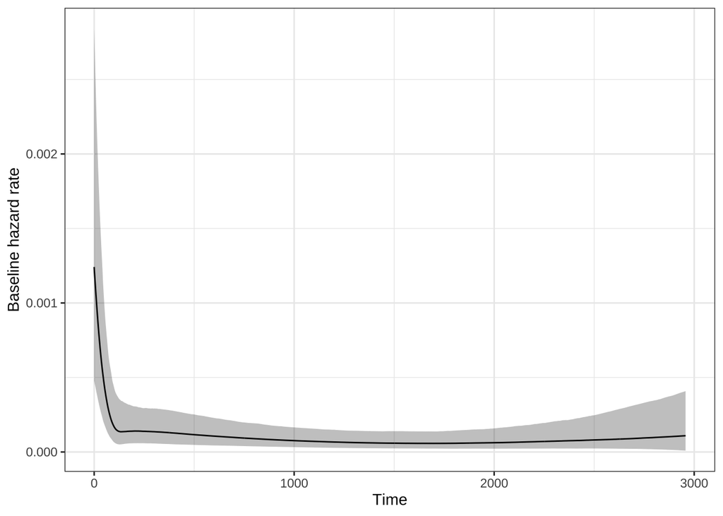

```r
plot(mod_clin_si_bias)
```

## Plots of model convergences

## Get results

```r
posterior_mod_clin_si_bias <- as.array(mod_clin_si_bias)
```

### a. Check trace plots for model

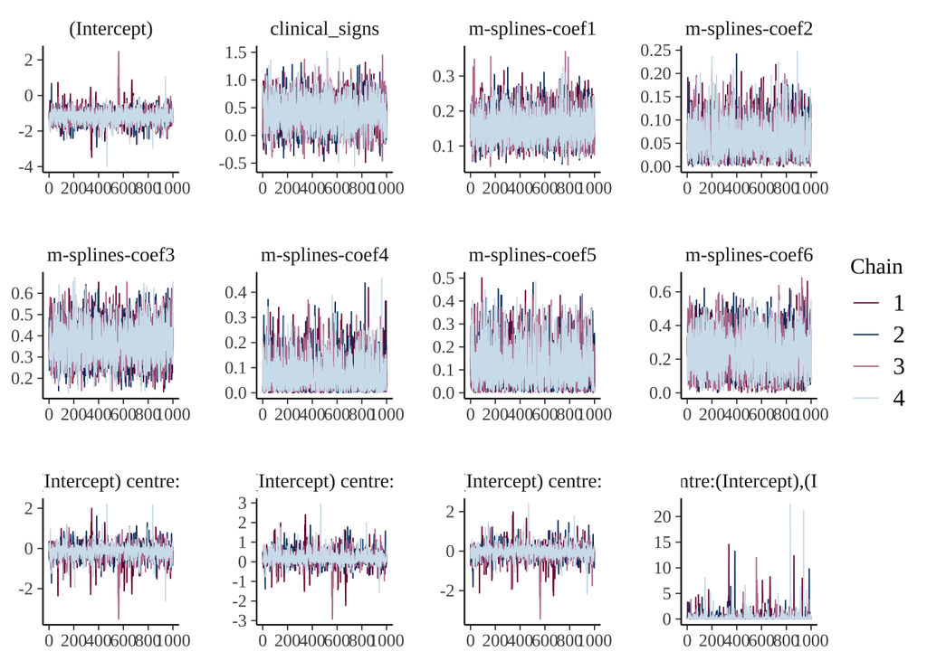

```r
color_scheme_set("mix-blue-pink")
mcmc_trace(posterior_mod_clin_si_bias)
```

### b. Trace rank plot

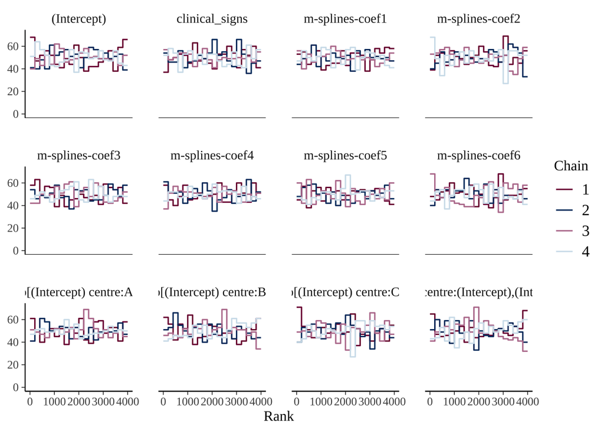

```r
mcmc_rank_overlay(posterior_mod_clin_si_bias)
```

### c. get dens overlay plot for chains

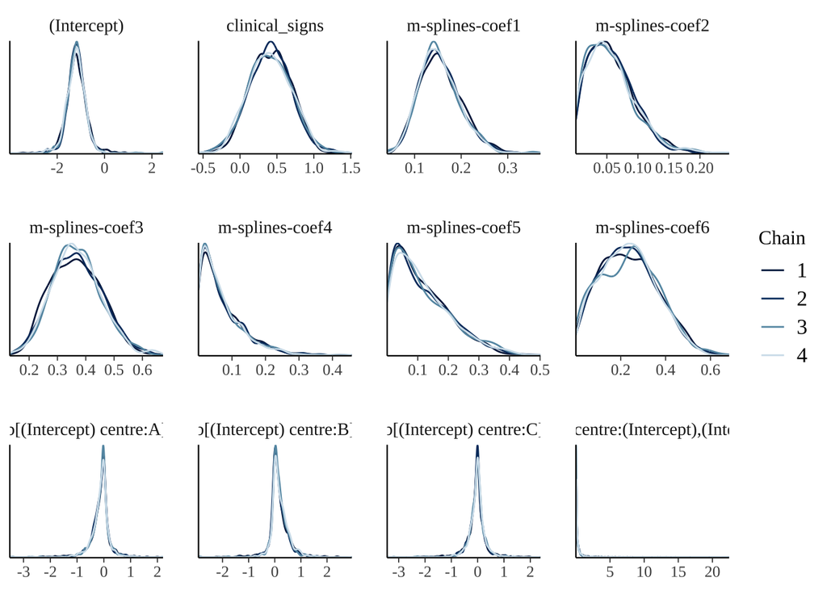

```r
color_scheme_set("blue")
mcmc_dens_overlay(posterior_mod_clin_si_bias)
```

## Summaries of coefficients

### HPDI for the different beta parameters

```r
draws <- as.matrix(mod_clin_si_bias)
median(draws[,2]) # 2nd column is draws for clinical_signs
```

```
## [1] 0.4059577
```

```r
HPDI(draws[,2], 0.97) # 2nd column is draws for clinical_signs
```

```
##      |0.97      0.97|
## -0.1793278  1.0364164
```

```r
HPDI(draws[,2], 0.89) # 2nd column is draws for clinical_signs
```

```
##       |0.89       0.89|
## -0.05201178  0.85724586
```

### Hypothesis tests on beta parameters

#### clinical_signs

probability that effect is positive

```r
mean(draws[,2] > 0) # 2nd column is draws for clinical_signs
```

```
## [1] 0.922
```

### a. Get HDI for coefficients

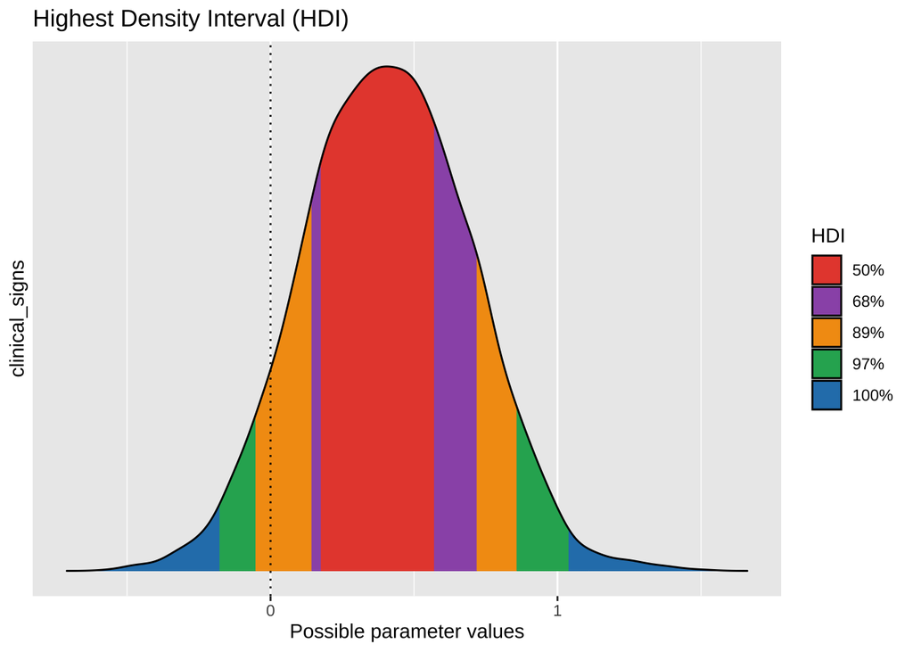

```r
hdi <- bayestestR::hdi(mod_clin_si_bias, ci = c(0.50, 0.68, 0.89, 0.97), parameters = "clinical_signs")
plot(hdi)
```

## Get density plots for posterior distributons of beta parameters

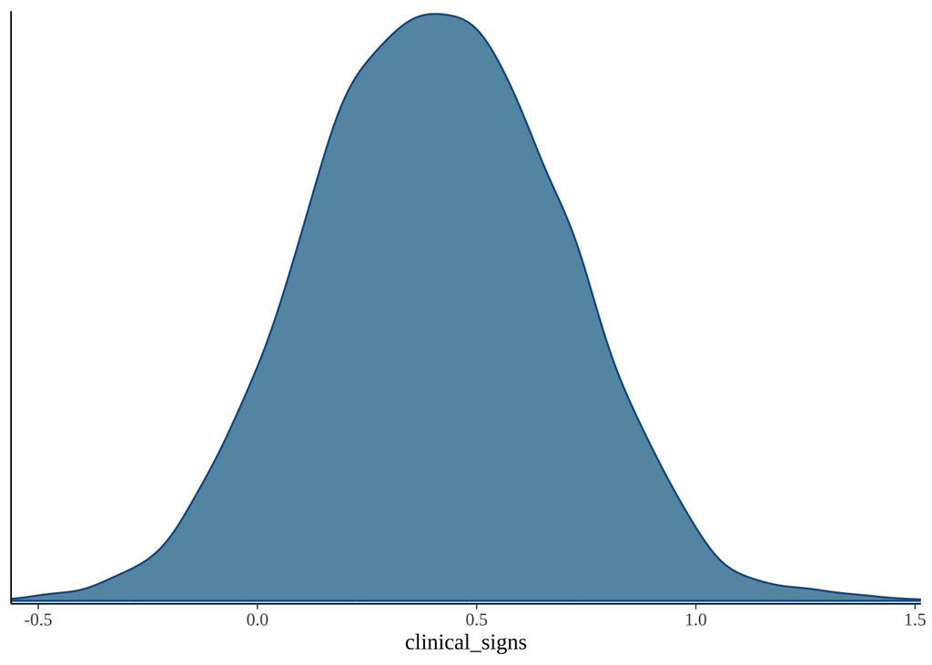

```r
mcmc_dens(posterior_mod_clin_si_bias,
  pars = c("clinical_signs"))
```

## Get area plot for posterior distributons of beta parameters

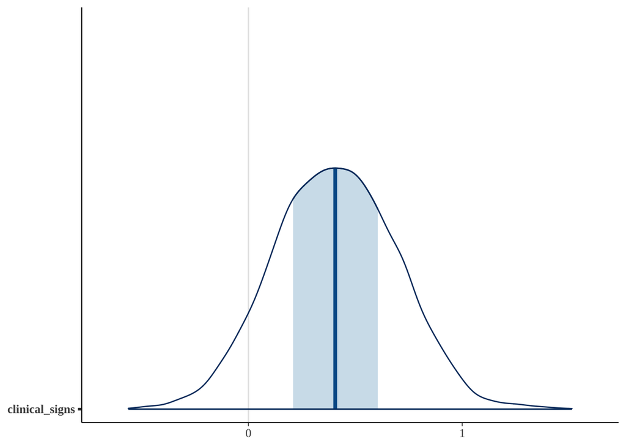

```r
mcmc_areas(posterior_mod_clin_si_bias,
  pars = "clinical_signs")
```

## Calculate hazard ratios for clinical_signs

### a. get posterior draws

```r
clinical_signs_hr <- exp(draws[,2]) # 2nd column is draws for clinical_signs)
```

### b. Summarise hazard ratios for clinical_signs

```r
median(clinical_signs_hr)
```

```
## [1] 1.500739
```

```r
hdi_clinical_signs_hr <- hdi(clinical_signs_hr, ci = c(0.97))
hdi_clinical_signs_hr
```

```
##           [,1]     [,2]
## [1,] 0.7969482 2.485202
```

### c. Plot posterior distribution for hazard ratio of clinical_signs

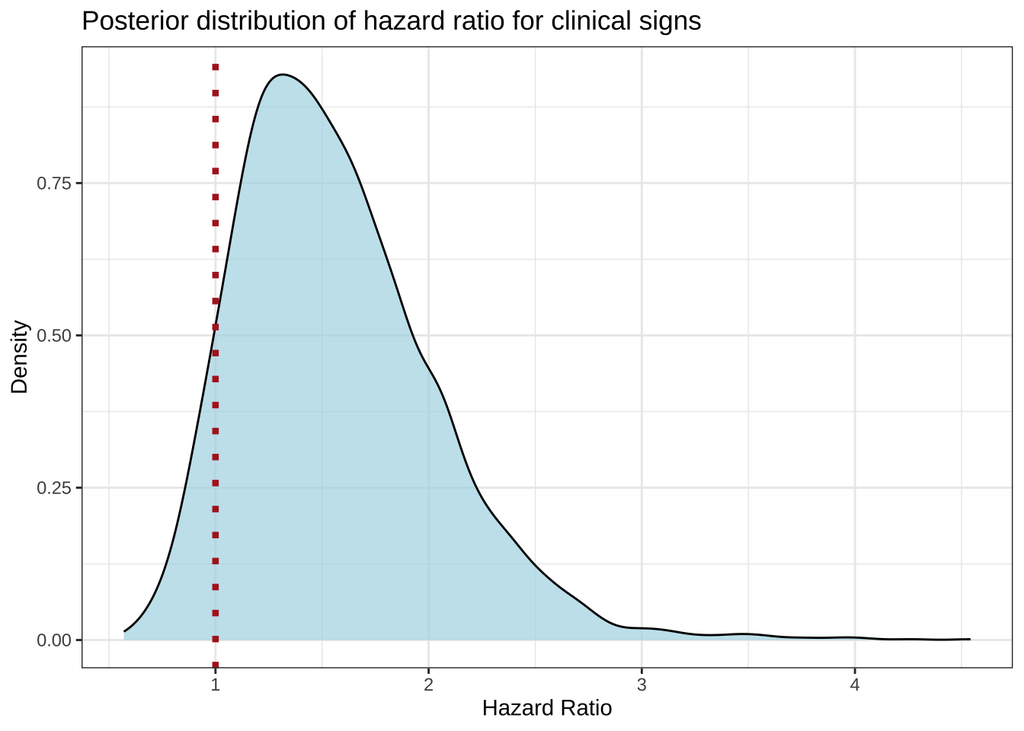

```r
ggplot(data.frame(clinical_signs_hr), aes(x = clinical_signs_hr)) +
  geom_density(fill = "lightblue", alpha = 0.7) +
  labs(title = "Posterior distribution of hazard ratio for clinical signs",
       x = "Hazard Ratio",
       y = "Density") +
  theme_bw() +
  geom_vline(xintercept = 1, linetype="dotted",
                color = "firebrick", linewidth = 1.5)
```

## Check model performance

### check performance of posterior probability

NB equivalent of pp_check

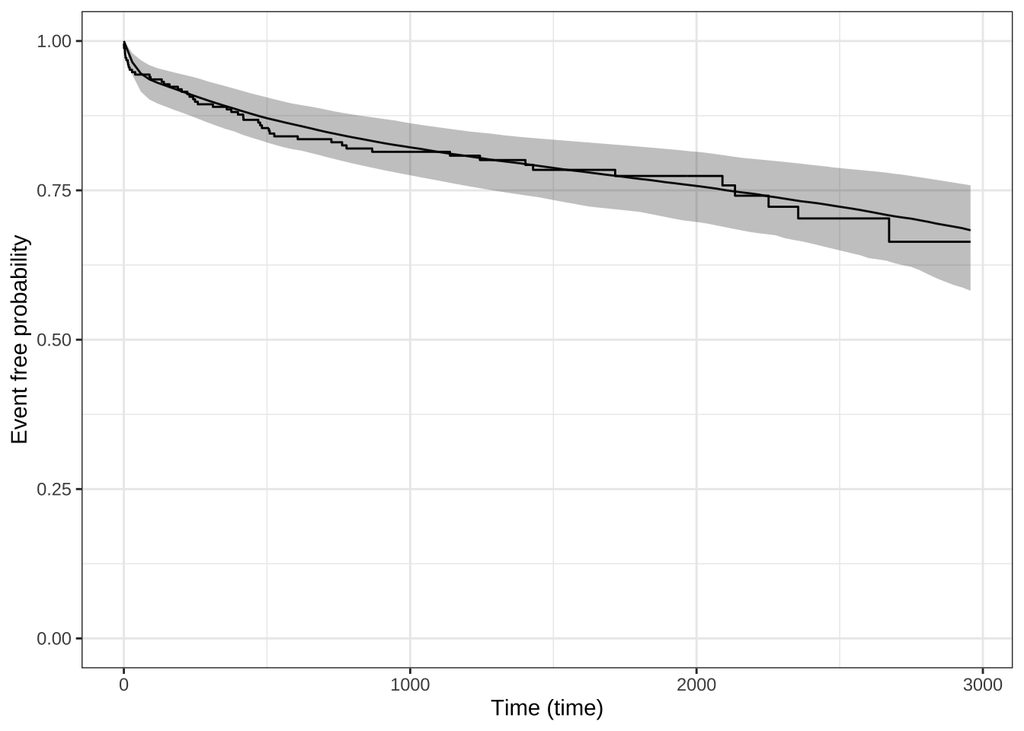

```r
ps_check(mod_clin_si_bias) |>
  suppressWarnings()
```

### check performance of prior probability

```r
mod_final_prior_only <- update(mod_clin_si_bias, prior_PD = TRUE)
```

[output not shown]

[output not shown]

[output not shown]

[output not shown]

[output not shown]

[output not shown]

[output not shown]

[output not shown]

[output not shown]

[output not shown]

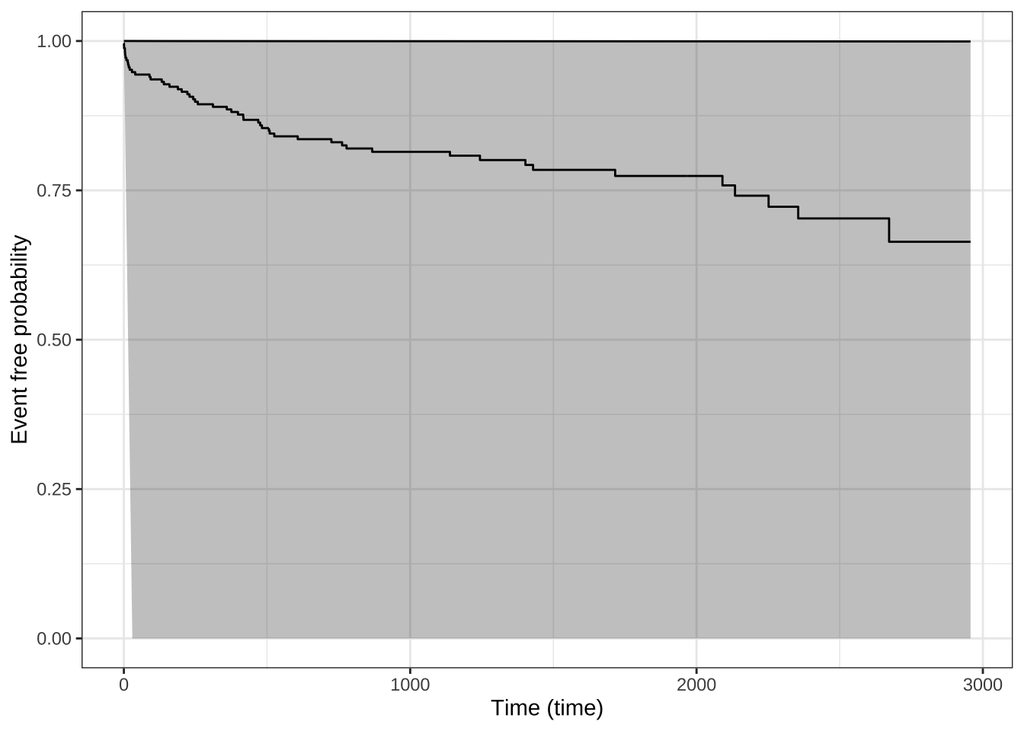

```r
ps_check(mod_final_prior_only) |>
  suppressWarnings()
```

## Make model predictions and plot for clinical_signs

### create new data where clinical_signs differs

```r
nd <- data.frame(centre = rep("A", 2),
                 clinical_signs = c(0, 1)
                 )
head(nd)
```

```
##   centre clinical_signs
## 1      A              0
## 2      A              1
```

### make posterior predictions from new data

```r
ps <- posterior_survfit(mod_clin_si_bias,
  newdata = nd,
  times = 0,
  extrapolate = TRUE) |>
  suppressWarnings()
head(ps)
```

```
## stan_surv predictions
##  num. individuals: 2
##  prediction type:  event free probability
##  standardised?:    no
##  conditional?:     no
##
##   id cond_time     time median  ci_lb  ci_ub
## 1  1        NA   0.0000 1.0000 1.0000 1.0000
## 2  1        NA  29.8679 0.9750 0.9502 0.9886
## 3  1        NA  59.7358 0.9621 0.9253 0.9824
## 4  1        NA  89.6037 0.9547 0.9150 0.9789
## 5  1        NA 119.4716 0.9502 0.9078 0.9759
## 6  1        NA 149.3395 0.9467 0.9028 0.9731
```

### plot

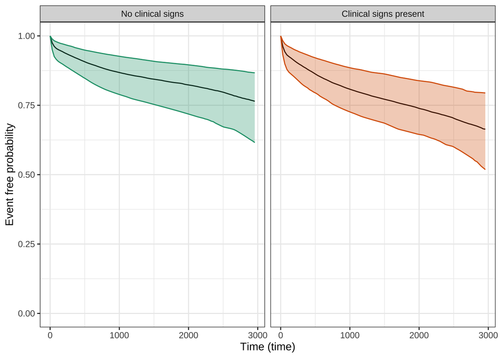

```r
panel_labels <- c('1' = "No clinical signs", '2' = "Clinical signs present")
pps <- plot(ps) +
  aes(colour = factor(id), fill = factor(id)) +
  scale_colour_brewer(palette = "Dark2") +
  scale_fill_brewer(palette = "Dark2") +
  theme(legend.position = "none") +
  facet_wrap(~ id, labeller = labeller(id = panel_labels))
print(pps)
```

## Check PH assumption visually

### make predictions of both the hazard and log hazard

```r
ph <- suppressWarnings(posterior_survfit(mod_clin_si_bias, newdata = nd, type = "haz"))
pl <- suppressWarnings(posterior_survfit(mod_clin_si_bias, newdata = nd, type = "loghaz"))
```

#### create plots

```r
pph <- plot(ph) +
  coord_cartesian(ylim = c(0.0, 0.005)) +
  facet_wrap(~ id, labeller = labeller(id = panel_labels))
```

```
## ℹ Adding new coordinate system, which will replace the existing one.
```

```r
ppl <- plot(pl) +
  facet_wrap(~ id, labeller = labeller(id = panel_labels))
```

#### combine plots in grid and plot

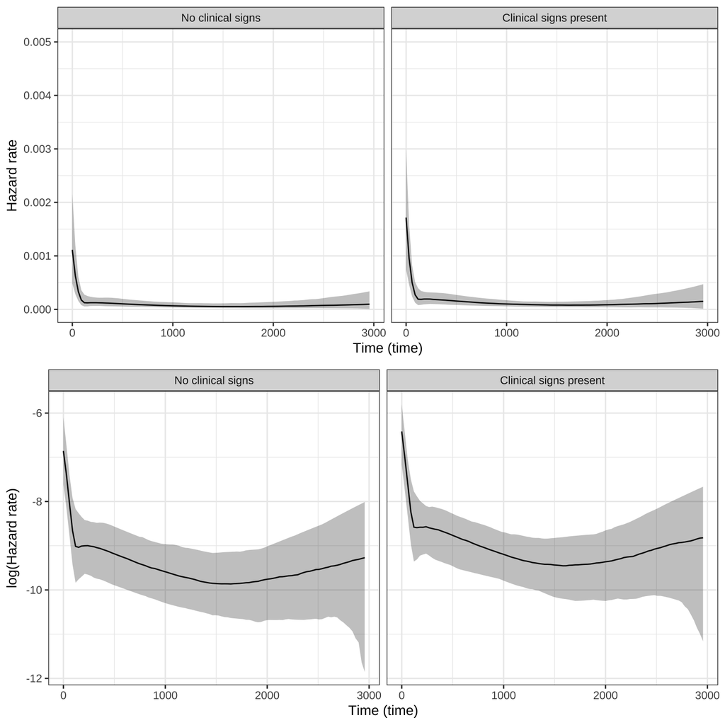

```r
plot_grid(pph, ppl, ncol = 1)
```

## Create KM curve for right clinical_signs

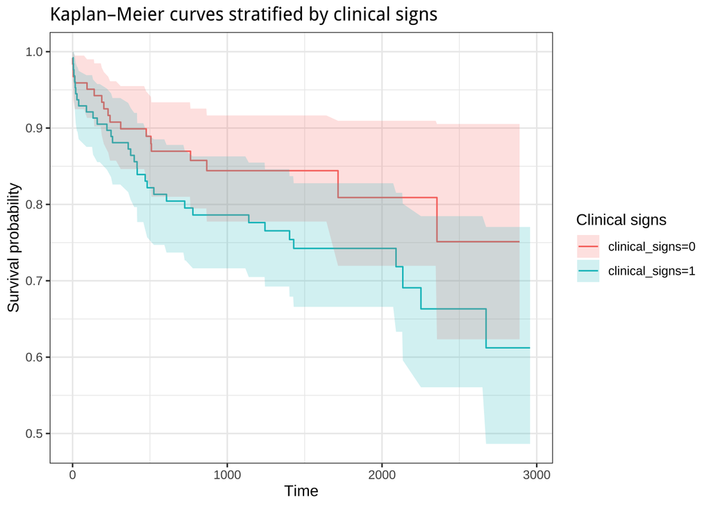

```r
# Basic KM curve for the entire dataset
km_strat <- survfit(Surv(time, status) ~ 1 + clinical_signs, data = sim_data2)

# Convert to tidy format
km_df <- broom::tidy(km_strat)


# Columns: time, estimate, conf.low, conf.high, strata, n.risk, n.event, n.censor
ggplot(km_df, aes(x = time, y = estimate, colour = strata, fill = strata)) +
  geom_step() +
  geom_ribbon(aes(ymin = conf.low, ymax = conf.high), alpha = 0.2, colour = NA) +
  theme_bw() +
  labs(
    x = "Time",
    y = "Survival probability",
    colour = "Clinical signs",
    fill = "Clinical signs",
    title = "Kaplan–Meier curves stratified by clinical signs"
  )
```

## Fit frequentist Cox PH model for effect of right clinical_signs

```r
# Fit Cox PH model
freq_cox_clinical_signs <- coxph(Surv(time, status) ~ 1 + clinical_signs + strata(centre),
                data = sim_data2)

summary(freq_cox_clinical_signs)
```

```
## Call:
## coxph(formula = Surv(time, status) ~ 1 + clinical_signs + strata(centre),
##     data = sim_data2)
##
##   n= 250, number of events= 53
##
##                  coef exp(coef) se(coef)     z Pr(>|z|)
## clinical_signs 0.3998    1.4915   0.2894 1.381    0.167
##
##                exp(coef) exp(-coef) lower .95 upper .95
## clinical_signs     1.491     0.6705    0.8458      2.63
##
## Concordance= 0.541  (se = 0.037 )
## Likelihood ratio test= 1.97  on 1 df,   p=0.2
## Wald test            = 1.91  on 1 df,   p=0.2
## Score (logrank) test = 1.93  on 1 df,   p=0.2
```

# III. Bayesian Cox’s regression for TRUE effect of CLINICAL SIGNS with random intercept for centre

## Non-informative prior for clinical_signs

```r
prior_clin_si <- student_t(df = 3,
                           location = 0,
                           scale = 2,
                           autoscale = FALSE)
```

## Fit model

NB use status … rstanarm requires the dead animals to be classified as 1, whilst censored are 0.

```r
mod_clin_si_true <- stan_surv(formula = Surv(time, status) ~ 1 + clinical_signs + chf + (1| centre),
  data = sim_data2,
  basehaz = "ms",
  prior = prior_clin_si,
  prior_intercept = normal(location = 0, scale = 20, autoscale = FALSE),
  prior_covariance =  decov(regularization = 2, concentration = 1, shape = 1, scale = 1),
  iter    = 2000,
  chains = 4,
  cores = 4,
  adapt_delta = 0.999,  # Often helpful for complex models
  seed = 666)
```

[output not shown]

[output not shown]

[output not shown]

[output not shown]

[output not shown]

[output not shown]

[output not shown]

[output not shown]

[output not shown]

## Summarise priors from model

```r
prior_summary(mod_clin_si_true)
```

```
## Priors for model 'mod_clin_si_true'
## ------
## Intercept
##  ~ normal(location = 0, scale = 20)
##
## Coefficients
##  ~ student_t(df = [3,3], location = [0,0], scale = [2,2])
##
## Auxiliary (M-spline-coefficients)
##  ~ dirichlet(concentration = [1,1,1,...])
##
## Covariance
##  ~ decov(reg. = 2, conc. = 1, shape = 1, scale = 1)
## ------
## See help('prior_summary.stanreg') for more details
```

## Model summary

```r
summary(mod_clin_si_true)
```

```
##
## Model Info:
##
##  function:        stan_surv
##  baseline hazard: M-splines on hazard scale
##  formula:         Surv(time, status) ~ 1 + clinical_signs + chf + (1 | centre)
##  algorithm:       sampling
##  sample:          4000 (posterior sample size)
##  priors:          see help('prior_summary')
##  observations:    250
##  events:          53 (21.2%)
##  right censored:  197 (78.8%)
##  delayed entry:   no
##
## Estimates:
##                                         mean   sd   10%   50%   90%
## (Intercept)                           -1.6    0.5 -2.1  -1.6  -1.0
## clinical_signs                         0.2    0.3 -0.2   0.2   0.5
## chf                                    0.7    0.3  0.3   0.7   1.2
## m-splines-coef1                        0.2    0.0  0.1   0.2   0.2
## m-splines-coef2                        0.1    0.0  0.0   0.1   0.1
## m-splines-coef3                        0.4    0.1  0.3   0.4   0.5
## m-splines-coef4                        0.1    0.1  0.0   0.0   0.1
## m-splines-coef5                        0.1    0.1  0.0   0.1   0.2
## m-splines-coef6                        0.2    0.1  0.1   0.2   0.4
## b[(Intercept) centre:A]               -0.1    0.4 -0.5  -0.1   0.2
## b[(Intercept) centre:B]                0.2    0.4 -0.1   0.1   0.6
## b[(Intercept) centre:C]               -0.1    0.4 -0.5   0.0   0.3
## Sigma[centre:(Intercept),(Intercept)]  0.4    1.1  0.0   0.1   0.9
##
## MCMC diagnostics
##                                       mcse Rhat n_eff
## (Intercept)                           0.0  1.0  1289
## clinical_signs                        0.0  1.0  3172
## chf                                   0.0  1.0  3082
## m-splines-coef1                       0.0  1.0  5270
## m-splines-coef2                       0.0  1.0  2374
## m-splines-coef3                       0.0  1.0  4159
## m-splines-coef4                       0.0  1.0  3987
## m-splines-coef5                       0.0  1.0  3402
## m-splines-coef6                       0.0  1.0  3162
## b[(Intercept) centre:A]               0.0  1.0  1126
## b[(Intercept) centre:B]               0.0  1.0   963
## b[(Intercept) centre:C]               0.0  1.0  1096
## Sigma[centre:(Intercept),(Intercept)] 0.0  1.0  1474
## log-posterior                         0.1  1.0  1023
##
## For each parameter, mcse is Monte Carlo standard error, n_eff is a crude measure of effective sample size, and Rhat is the potential scale reduction factor on split chains (at convergence Rhat=1).
```

## Model short summary

```r
print(mod_clin_si_true, digits = 3)
```

```
## stan_surv
##  baseline hazard: M-splines on hazard scale
##  formula:         Surv(time, status) ~ 1 + clinical_signs + chf + (1 | centre)
##  observations:    250
##  events:          53 (21.2%)
##  right censored:  197 (78.8%)
##  delayed entry:   no
## ------
##                 Median MAD_SD exp(Median)
## (Intercept)     -1.568  0.407     NA
## clinical_signs   0.150  0.307  1.162
## chf              0.715  0.339  2.044
## m-splines-coef1  0.165  0.046     NA
## m-splines-coef2  0.059  0.043     NA
## m-splines-coef3  0.384  0.087     NA
## m-splines-coef4  0.047  0.047     NA
## m-splines-coef5  0.083  0.080     NA
## m-splines-coef6  0.208  0.125     NA
##
## Error terms:
##  Groups Name        Std.Dev.
##  centre (Intercept) 0.6087
## Num. levels: centre 3
##
## ------
## * For help interpreting the printed output see ?print.stanreg
## * For info on the priors used see ?prior_summary.stanreg
```

## Plot Baseline hazard of model

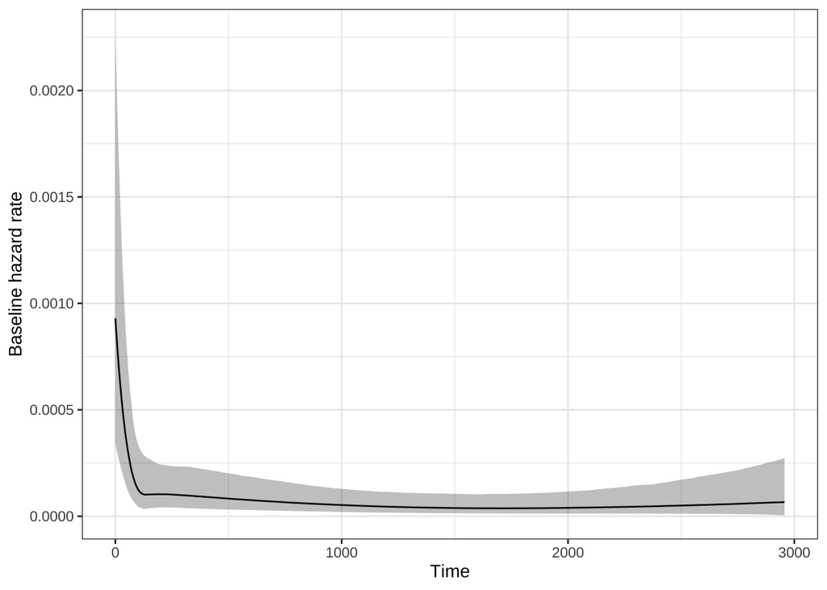

```r
plot(mod_clin_si_true)
```

## Plots of model convergences

## Get results

```r
posterior_mod_clin_si_true <- as.array(mod_clin_si_true)
```

### a. Check trace plots for model

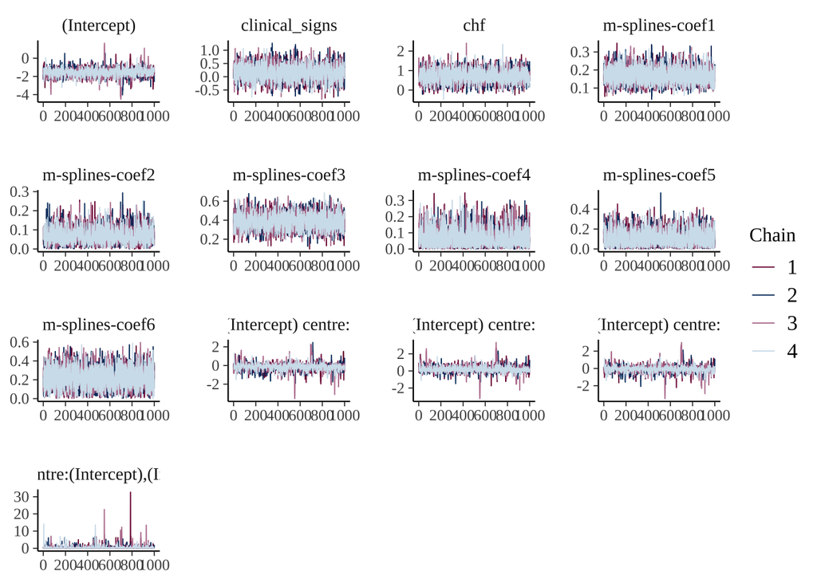

```r
color_scheme_set("mix-blue-pink")
mcmc_trace(posterior_mod_clin_si_true)
```

### b. Trace rank plot

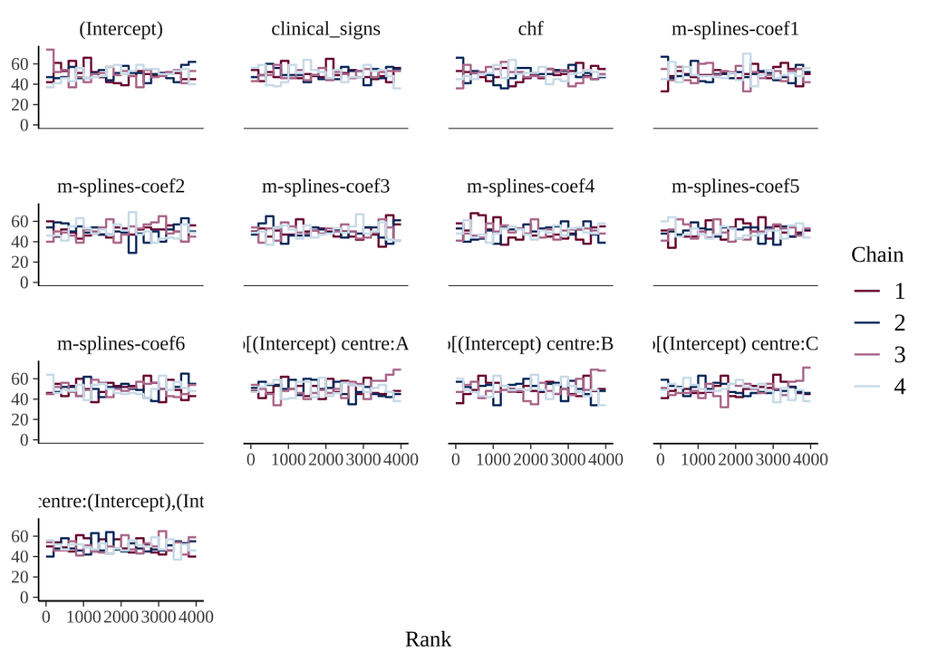

```r
mcmc_rank_overlay(posterior_mod_clin_si_true)
```

### c. get dens overlay plot for chains

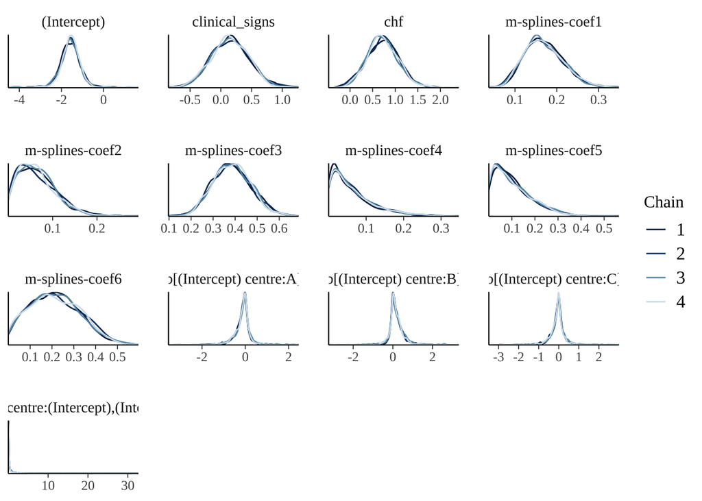

```r
color_scheme_set("blue")
mcmc_dens_overlay(posterior_mod_clin_si_true)
```

## Summaries of coefficients

### HPDI for the different beta parameters

```r
draws <- as.matrix(mod_clin_si_true)
median(draws[,2]) # 2nd column is draws for clinical_signs
```

```
## [1] 0.1500222
```

```r
HPDI(draws[,2], 0.97) # 2nd column is draws for clinical_signs
```

```
##      |0.97      0.97|
## -0.4902607  0.8313432
```

```r
HPDI(draws[,2], 0.89) # 2nd column is draws for clinical_signs
```

```
##      |0.89      0.89|
## -0.3022469  0.6552353
```

### Hypothesis tests on beta parameters

#### clinical_signs

probability that effect is positive

```r
mean(draws[,2] > 0) # 2nd column is draws for clinical_signs
```

```
## [1] 0.687
```

### a. Get HDI for coefficients

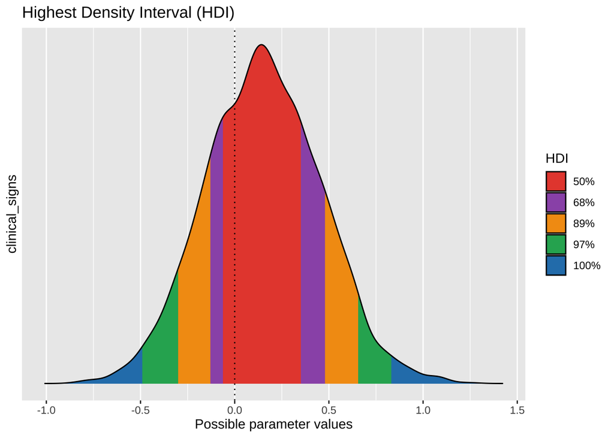

```r
hdi <- bayestestR::hdi(mod_clin_si_true, ci = c(0.50, 0.68, 0.89, 0.97), parameters = "clinical_signs")
plot(hdi)
```

## Get density plots for posterior distributons of beta parameters

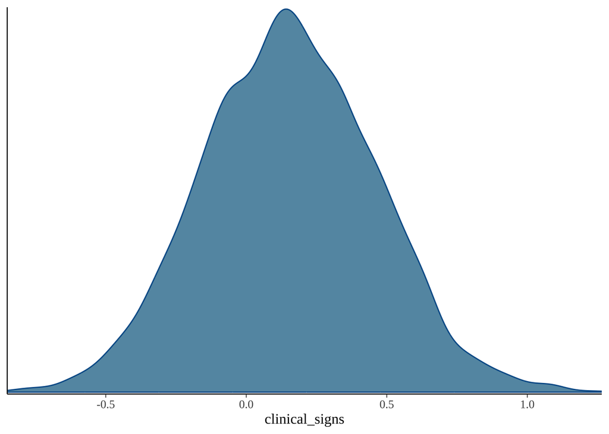

```r
mcmc_dens(posterior_mod_clin_si_true,
  pars = c("clinical_signs"))
```

## Get area plot for posterior distributons of beta parameters

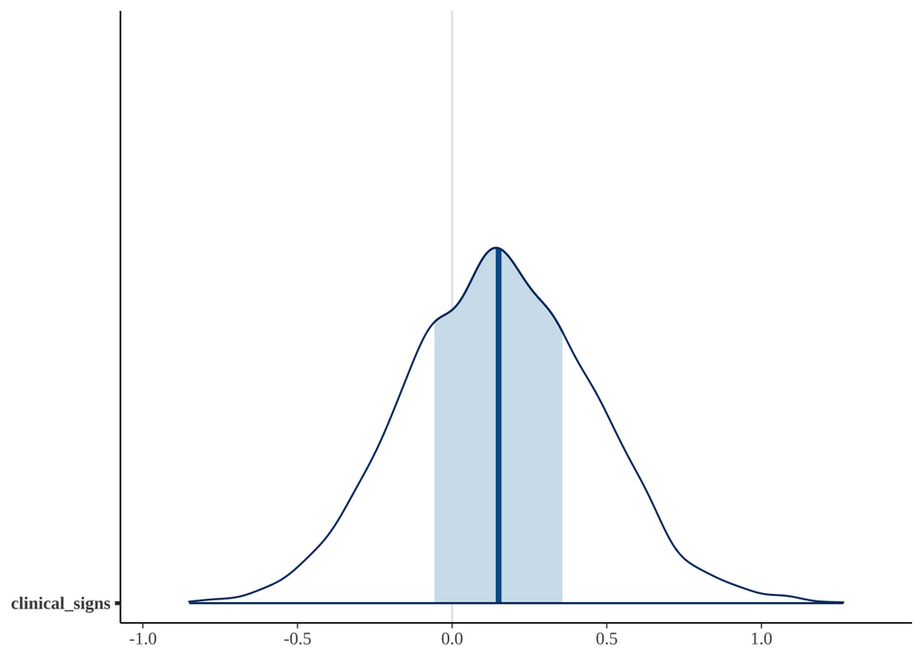

```r
mcmc_areas(posterior_mod_clin_si_true,
  pars = "clinical_signs")
```

## Calculate hazard ratios for clinical_signs

### a. get posterior draws

```r
clinical_signs_hr <- exp(draws[,2]) # 2nd column is draws for clinical_signs)
```

### b. Summarise hazard ratios for clinical_signs

```r
median(clinical_signs_hr)
```

```
## [1] 1.16186
```

```r
hdi_clinical_signs_hr <- hdi(clinical_signs_hr, ci = c(0.97))
hdi_clinical_signs_hr
```

```
##           [,1]     [,2]
## [1,] 0.5902509 1.964136
```

### c. Plot posterior distribution for hazard ratio of clinical_signs

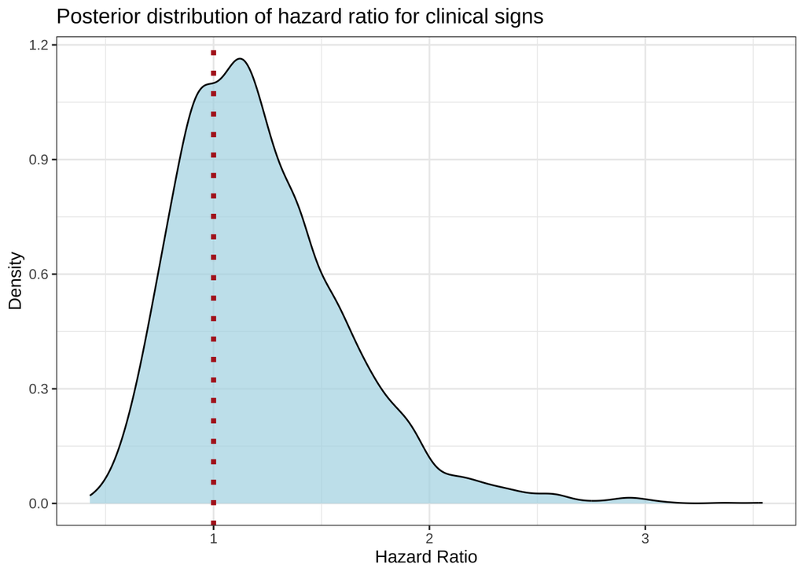

```r
ggplot(data.frame(clinical_signs_hr), aes(x = clinical_signs_hr)) +
  geom_density(fill = "lightblue", alpha = 0.7) +
  labs(title = "Posterior distribution of hazard ratio for clinical signs",
       x = "Hazard Ratio",
       y = "Density") +
  theme_bw() +
  geom_vline(xintercept = 1, linetype="dotted",
                color = "firebrick", linewidth = 1.5)
```

## Check model performance

### check performance of posterior probability

NB equivalent of pp_check

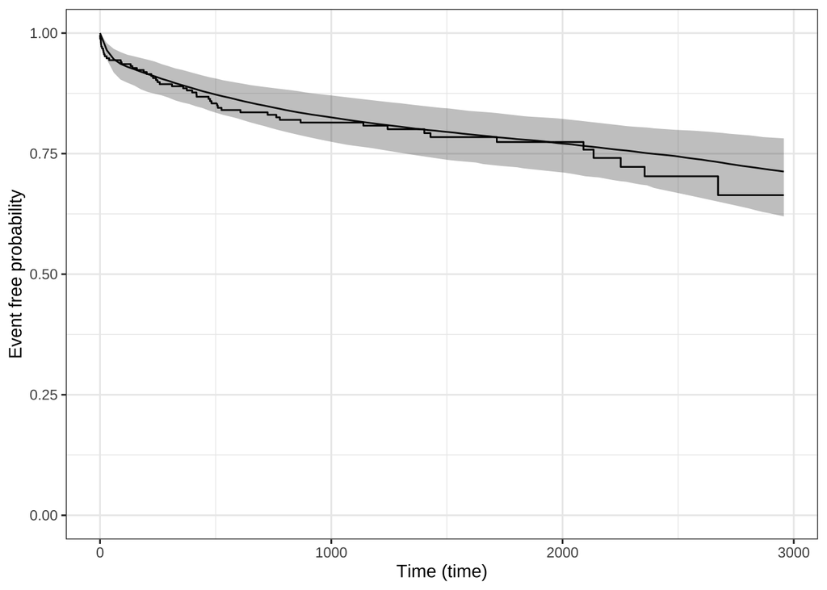

```r
ps_check(mod_clin_si_true) |>
  suppressWarnings()
```

### check performance of prior probability

```r
mod_final_prior_only <- update(mod_clin_si_true, prior_PD = TRUE)
```

[output not shown]

[output not shown]

[output not shown]

[output not shown]

[output not shown]

[output not shown]

[output not shown]

[output not shown]

[output not shown]

[output not shown]

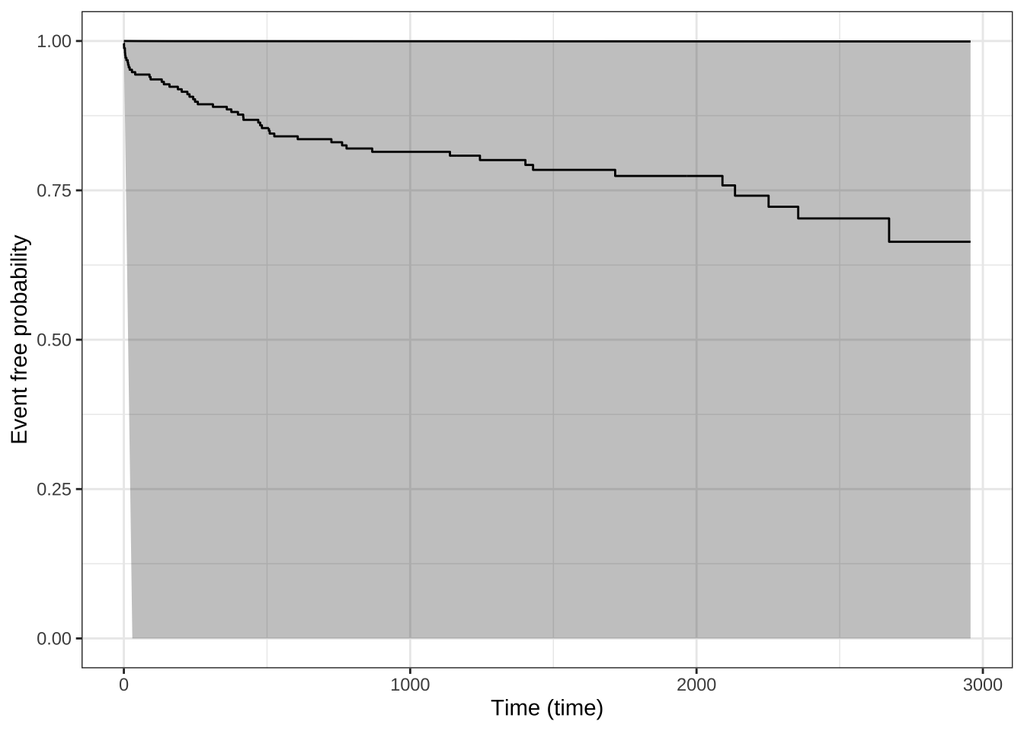

```r
ps_check(mod_final_prior_only) |>
  suppressWarnings()
```

## Make model predictions and plot for clinical_signs

### create new data where clinical_signs differs

```r
nd <- data.frame(centre = rep("A", 2),
                 clinical_signs = c(0, 1),
                 chf = rep(0, 2)
                 )
head(nd)
```

```
##   centre clinical_signs chf
## 1      A              0   0
## 2      A              1   0
```

### make posterior predictions from new data

```r
ps <- posterior_survfit(mod_clin_si_true,
  newdata = nd,
  times = 0,
  extrapolate = TRUE) |>
  suppressWarnings()
head(ps)
```

```
## stan_surv predictions
##  num. individuals: 2
##  prediction type:  event free probability
##  standardised?:    no
##  conditional?:     no
##
##   id cond_time     time median  ci_lb  ci_ub
## 1  1        NA   0.0000 1.0000 1.0000 1.0000
## 2  1        NA  29.8679 0.9813 0.9611 0.9918
## 3  1        NA  59.7358 0.9715 0.9411 0.9870
## 4  1        NA  89.6037 0.9658 0.9310 0.9846
## 5  1        NA 119.4716 0.9630 0.9240 0.9831
## 6  1        NA 149.3395 0.9611 0.9203 0.9817
```

### plot

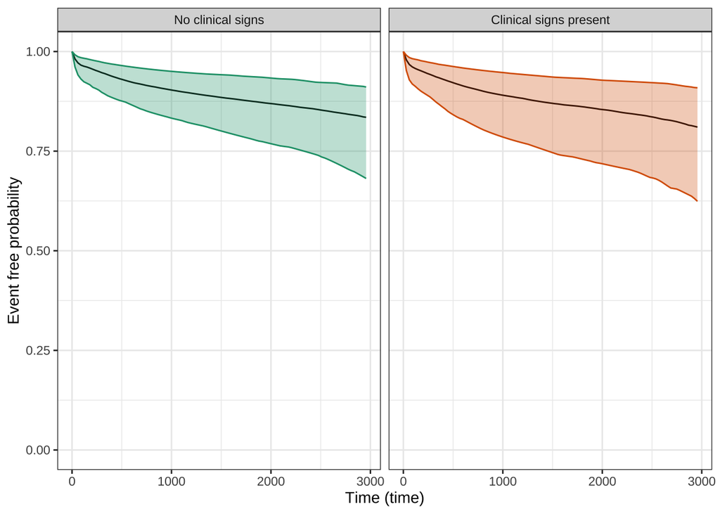

```r
panel_labels <- c('1' = "No clinical signs", '2' = "Clinical signs present")
pps <- plot(ps) +
  aes(colour = factor(id), fill = factor(id)) +
  scale_colour_brewer(palette = "Dark2") +
  scale_fill_brewer(palette = "Dark2") +
  theme(legend.position = "none") +
  facet_wrap(~ id, labeller = labeller(id = panel_labels))
print(pps)
```

## Check PH assumption visually

### make predictions of both the hazard and log hazard

```r
ph <- suppressWarnings(posterior_survfit(mod_clin_si_true, newdata = nd, type = "haz"))
pl <- suppressWarnings(posterior_survfit(mod_clin_si_true, newdata = nd, type = "loghaz"))
```

#### create plots

```r
pph <- plot(ph) +
  coord_cartesian(ylim = c(0.0, 0.005)) +
  facet_wrap(~ id, labeller = labeller(id = panel_labels))
```

```
## ℹ Adding new coordinate system, which will replace the existing one.
```

```r
ppl <- plot(pl) +
  facet_wrap(~ id, labeller = labeller(id = panel_labels))
```

#### combine plots in grid and plot

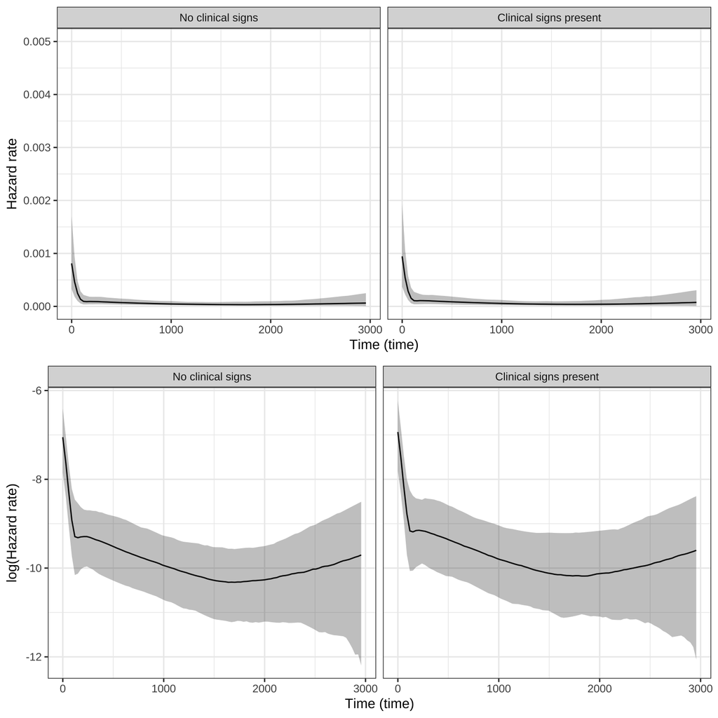

```r
plot_grid(pph, ppl, ncol = 1)
```

## Create KM curve for right clinical_signs

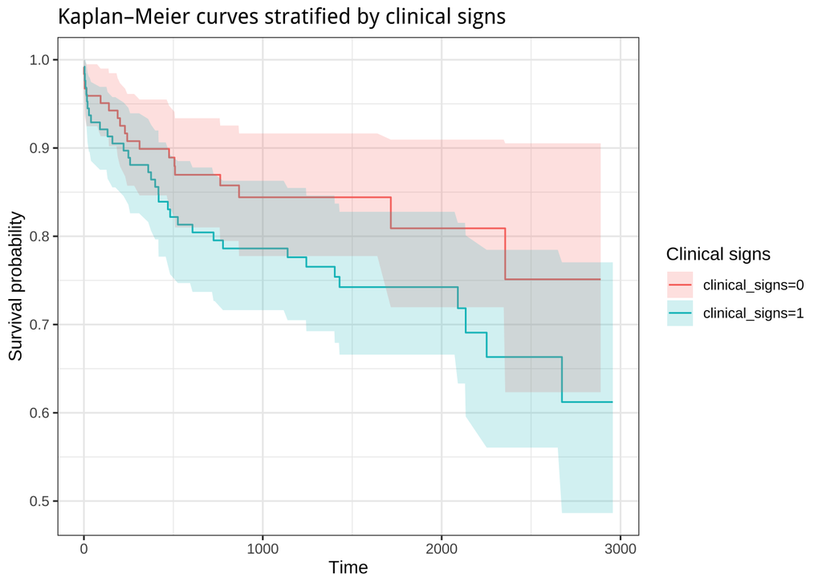

```r
# Basic KM curve for the entire dataset
km_strat <- survfit(Surv(time, status) ~ 1 + clinical_signs, data = sim_data2)

# Convert to tidy format
km_df <- broom::tidy(km_strat)


# Columns: time, estimate, conf.low, conf.high, strata, n.risk, n.event, n.censor
ggplot(km_df, aes(x = time, y = estimate, colour = strata, fill = strata)) +
  geom_step() +
  geom_ribbon(aes(ymin = conf.low, ymax = conf.high), alpha = 0.2, colour = NA) +
  theme_bw() +
  labs(
    x = "Time",
    y = "Survival probability",
    colour = "Clinical signs",
    fill = "Clinical signs",
    title = "Kaplan–Meier curves stratified by clinical signs"
  )
```

## Fit frequentist Cox PH model for effect of right clinical_signs

```r
# Fit Cox PH model
freq_cox_clinical_signs <- coxph(Surv(time, status) ~ 1 + clinical_signs + chf + strata(centre),
                data = sim_data2)

summary(freq_cox_clinical_signs)
```

```
## Call:
## coxph(formula = Surv(time, status) ~ 1 + clinical_signs + chf +
##     strata(centre), data = sim_data2)
##
##   n= 250, number of events= 53
##
##                  coef exp(coef) se(coef)     z Pr(>|z|)
## clinical_signs 0.1126    1.1192   0.3130 0.360   0.7189
## chf            0.7909    2.2055   0.3574 2.213   0.0269 *
## ---
## Signif. codes:  0 '***' 0.001 '**' 0.01 '*' 0.05 '.' 0.1 ' ' 1
##
##                exp(coef) exp(-coef) lower .95 upper .95
## clinical_signs     1.119     0.8935    0.6061     2.067
## chf                2.205     0.4534    1.0947     4.443
##
## Concordance= 0.597  (se = 0.04 )
## Likelihood ratio test= 7.22  on 2 df,   p=0.03
## Wald test            = 6.59  on 2 df,   p=0.04
## Score (logrank) test = 6.97  on 2 df,   p=0.03
```

# 5. Check effects in dataset 3

# I. Bayesian Cox’s regression for TOTAL effect of RIGHT CHF with random intercept for centre

NB effect of chf amplified because additional effect of clinical signs

## Non-informative prior for chf

### i.chf

```r
prior_chf3 <- student_t(df = 3,
                       location = 0,
                       scale = 2,
                       autoscale = TRUE)
```

## Fit model

NB use status … rstanarm requires the dead animals to be classified as 1, whilst censored are 0.

```r
mod_chf3 <- stan_surv(formula = Surv(time, status) ~ 1 + chf + (1| centre),
  data = sim_data3,
  basehaz = "ms",
  prior = prior_chf3,
  prior_intercept = normal(location = 0, scale = 10, autoscale = FALSE),
  prior_covariance =  decov(regularization = 2, concentration = 1, shape = 1, scale = 1),
  iter    = 2000,
  chains = 4,
  cores = 4,
  adapt_delta = 0.999,  # Often helpful for complex models
  seed = 666)
```

[output not shown]

[output not shown]

[output not shown]

[output not shown]

[output not shown]

[output not shown]

[output not shown]

[output not shown]

[output not shown]

[output not shown]

## Summarise priors from model

```r
prior_summary(mod_chf3)
```

```
## Priors for model 'mod_chf3'
## ------
## Intercept
##  ~ normal(location = 0, scale = 10)
##
## Coefficients
##  ~ student_t(df = 3, location = 0, scale = 2)
##
## Auxiliary (M-spline-coefficients)
##  ~ dirichlet(concentration = [1,1,1,...])
##
## Covariance
##  ~ decov(reg. = 2, conc. = 1, shape = 1, scale = 1)
## ------
## See help('prior_summary.stanreg') for more details
```

## Model summary

```r
summary(mod_chf3)
```

```
##
## Model Info:
##
##  function:        stan_surv
##  baseline hazard: M-splines on hazard scale
##  formula:         Surv(time, status) ~ 1 + chf + (1 | centre)
##  algorithm:       sampling
##  sample:          4000 (posterior sample size)
##  priors:          see help('prior_summary')
##  observations:    250
##  events:          61 (24.4%)
##  right censored:  189 (75.6%)
##  delayed entry:   no
##
## Estimates:
##                                         mean   sd   10%   50%   90%
## (Intercept)                           -1.4    0.4 -1.9  -1.4  -0.9
## chf                                    0.8    0.3  0.4   0.8   1.2
## m-splines-coef1                        0.2    0.0  0.1   0.2   0.2
## m-splines-coef2                        0.1    0.1  0.1   0.1   0.2
## m-splines-coef3                        0.3    0.1  0.2   0.3   0.5
## m-splines-coef4                        0.1    0.1  0.0   0.1   0.2
## m-splines-coef5                        0.1    0.1  0.0   0.1   0.3
## m-splines-coef6                        0.2    0.1  0.0   0.1   0.3
## b[(Intercept) centre:A]               -0.1    0.3 -0.4   0.0   0.2
## b[(Intercept) centre:B]                0.2    0.3 -0.1   0.1   0.6
## b[(Intercept) centre:C]               -0.1    0.3 -0.4   0.0   0.2
## Sigma[centre:(Intercept),(Intercept)]  0.3    0.7  0.0   0.1   0.6
##
## MCMC diagnostics
##                                       mcse Rhat n_eff
## (Intercept)                           0.0  1.0  1601
## chf                                   0.0  1.0  3132
## m-splines-coef1                       0.0  1.0  5731
## m-splines-coef2                       0.0  1.0  2976
## m-splines-coef3                       0.0  1.0  3254
## m-splines-coef4                       0.0  1.0  2362
## m-splines-coef5                       0.0  1.0  3024
## m-splines-coef6                       0.0  1.0  3212
## b[(Intercept) centre:A]               0.0  1.0  1610
## b[(Intercept) centre:B]               0.0  1.0  1444
## b[(Intercept) centre:C]               0.0  1.0  1598
## Sigma[centre:(Intercept),(Intercept)] 0.0  1.0  1764
## log-posterior                         0.1  1.0  1081
##
## For each parameter, mcse is Monte Carlo standard error, n_eff is a crude measure of effective sample size, and Rhat is the potential scale reduction factor on split chains (at convergence Rhat=1).
```

## Model short summary

```r
print(mod_chf3, digits = 3)
```

```
## stan_surv
##  baseline hazard: M-splines on hazard scale
##  formula:         Surv(time, status) ~ 1 + chf + (1 | centre)
##  observations:    250
##  events:          61 (24.4%)
##  right censored:  189 (75.6%)
##  delayed entry:   no
## ------
##                 Median MAD_SD exp(Median)
## (Intercept)     -1.393  0.374     NA
## chf              0.810  0.308  2.247
## m-splines-coef1  0.153  0.042     NA
## m-splines-coef2  0.117  0.055     NA
## m-splines-coef3  0.321  0.095     NA
## m-splines-coef4  0.087  0.081     NA
## m-splines-coef5  0.123  0.100     NA
## m-splines-coef6  0.133  0.112     NA
##
## Error terms:
##  Groups Name        Std.Dev.
##  centre (Intercept) 0.5135
## Num. levels: centre 3
##
## ------
## * For help interpreting the printed output see ?print.stanreg
## * For info on the priors used see ?prior_summary.stanreg
```

## Plot Baseline hazard of model

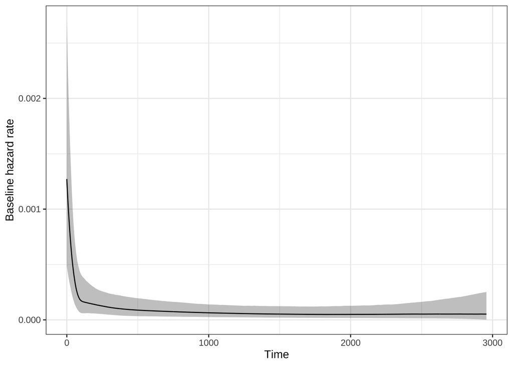

```r
plot(mod_chf3)
```

## Plots of model convergences

## Get results

```r
posterior_mod_chf3 <- as.array(mod_chf3)
```

### a. Check trace plots for model

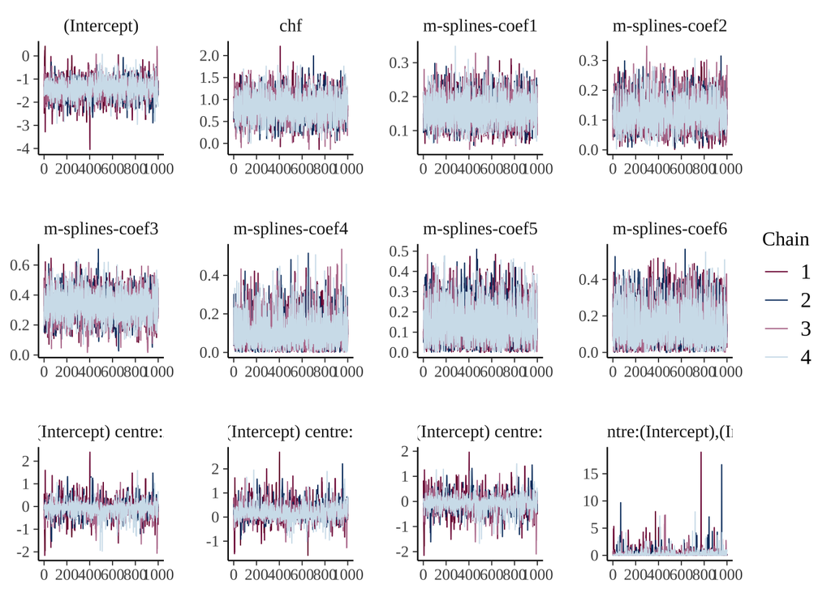

```r
color_scheme_set("mix-blue-pink")
mcmc_trace(posterior_mod_chf3)
```

### b. Trace rank plot

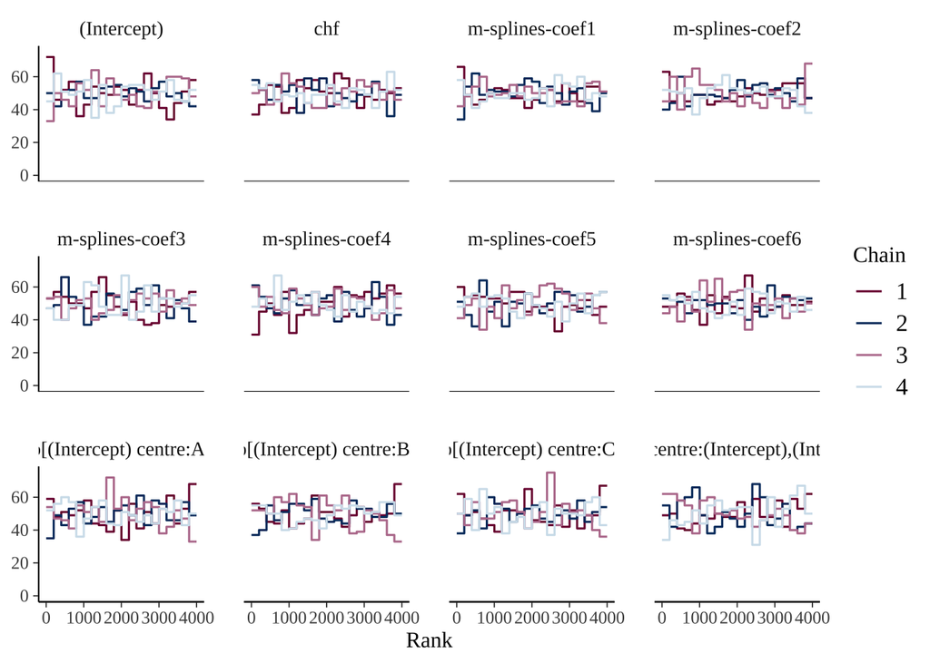

```r
mcmc_rank_overlay(posterior_mod_chf3)
```

### c. get dens overlay plot for chains

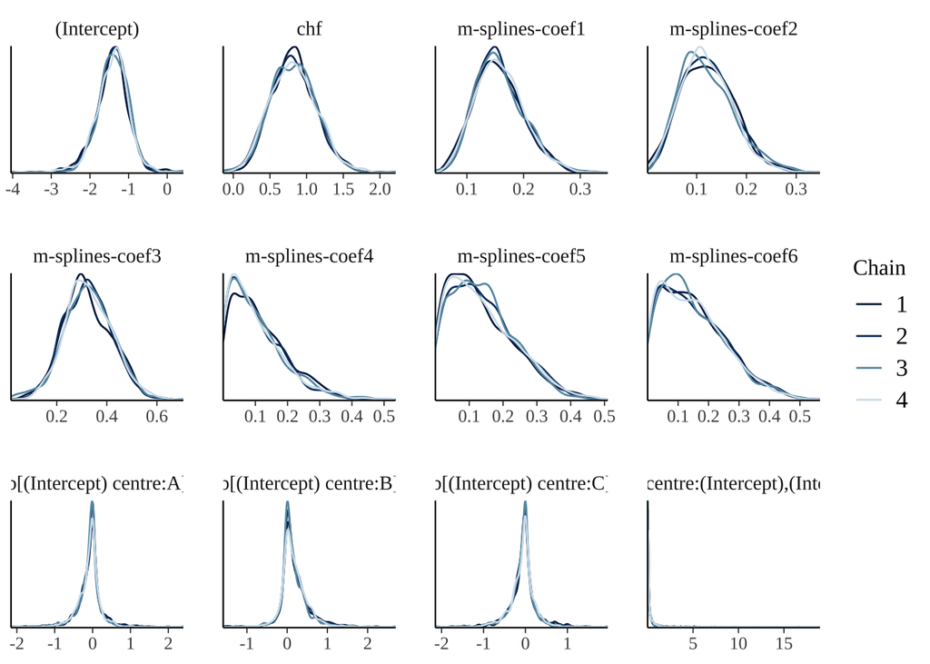

```r
color_scheme_set("blue")
mcmc_dens_overlay(posterior_mod_chf3)
```

## Summaries of coefficients

### HPDI for the different beta parameters

```r
draws <- as.matrix(mod_chf3)
median(draws[,2]) # 2nd column is draws for chf
```

```
## [1] 0.8095446
```

```r
HPDI(draws[,2], 0.97) # 2nd column is draws for chf
```

```
##     |0.97     0.97|
## 0.1974128 1.5124399
```

```r
HPDI(draws[,2], 0.89) # 2nd column is draws for chf
```

```
##     |0.89     0.89|
## 0.3476835 1.3058480
```

### Hypothesis tests on beta parameters

#### chf

probability that effect is positive

```r
mean(draws[,2] > 0) # 2nd column is draws for chf
```

```
## [1] 0.99825
```

### a. Get HDI for coefficients

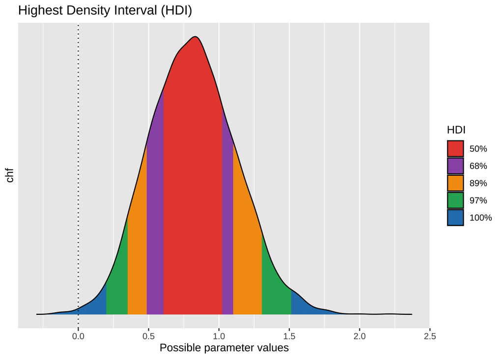

```r
hdi <- bayestestR::hdi(mod_chf3, ci = c(0.50, 0.68, 0.89, 0.97), parameters = "chf")
plot(hdi)
```

## Get density plots for posterior distributons of beta parameters

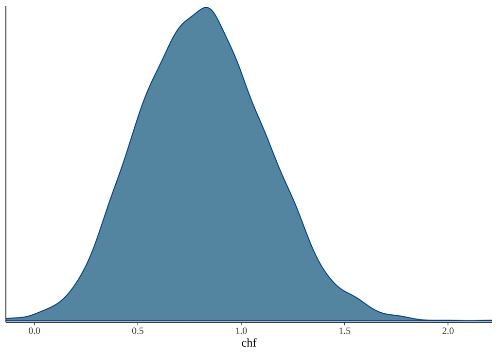

```r
mcmc_dens(posterior_mod_chf3,
  pars = c("chf"))
```

## Get area plot for posterior distributons of beta parameters

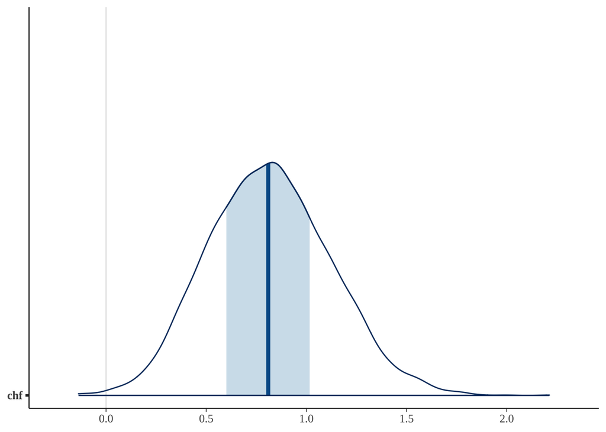

```r
mcmc_areas(posterior_mod_chf3,
  pars = "chf")
```

## Calculate hazard ratios for chf

### a. get posterior draws

```r
chf_hr3 <- exp(draws[,2]) # 2nd column is draws for chf)
```

### b. Summarise hazard ratios for chf

```r
median(chf_hr3)
```

```
## [1] 2.246884
```

```r
hdi_chf_hr3 <- hdi(chf_hr3, ci = c(0.97))
hdi_chf_hr3
```

```
##          [,1]     [,2]
## [1,] 1.165227 3.894783
```

### c. Plot posterior distribution for hazard ratio of chf

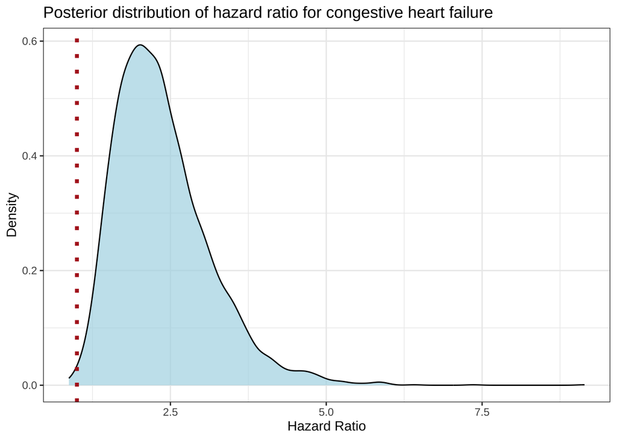

```r
ggplot(data.frame(chf_hr3), aes(x = chf_hr3)) +
  geom_density(fill = "lightblue", alpha = 0.7) +
  labs(title = "Posterior distribution of hazard ratio for congestive heart failure",
       x = "Hazard Ratio",
       y = "Density") +
  theme_bw() +
  geom_vline(xintercept = 1, linetype="dotted",
                color = "firebrick", linewidth = 1.5)
```

## Check model performance

### check performance of posterior probability

NB equivalent of pp_check

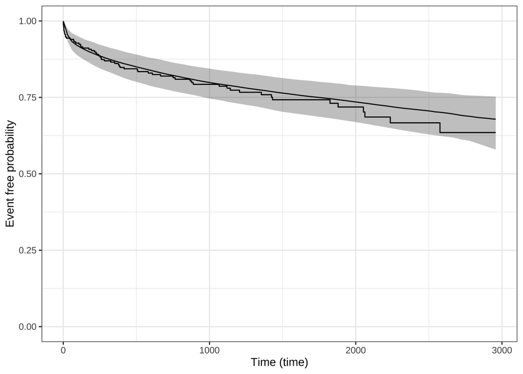

```r
ps_check(mod_chf3) |>
  suppressWarnings()
```

### check performance of prior probability

```r
mod_final_prior_only <- update(mod_chf3, prior_PD = TRUE)
```

[output not shown]

[output not shown]

[output not shown]

[output not shown]

[output not shown]

[output not shown]

[output not shown]

[output not shown]

[output not shown]

[output not shown]

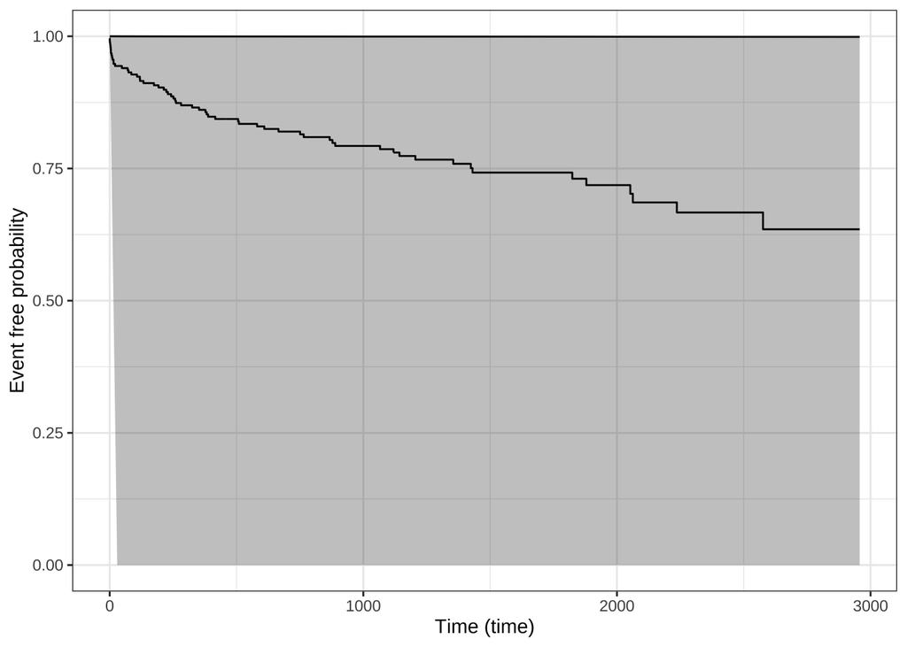

```r
ps_check(mod_final_prior_only) |>
  suppressWarnings()
```

## Make model predictions and plot for chf

### create new data where chf differs

```r
nd <- data.frame(centre = rep("A", 2),
                 chf = c(0, 1)
                 )
head(nd)
```

```
##   centre chf
## 1      A   0
## 2      A   1
```

### make posterior predictions from new data

```r
ps <- posterior_survfit(mod_chf3,
  newdata = nd,
  times = 0,
  extrapolate = TRUE) |>
  suppressWarnings()
head(ps)
```

```
## stan_surv predictions
##  num. individuals: 2
##  prediction type:  event free probability
##  standardised?:    no
##  conditional?:     no
##
##   id cond_time     time median  ci_lb  ci_ub
## 1  1        NA   0.0000 1.0000 1.0000 1.0000
## 2  1        NA  29.8679 0.9753 0.9533 0.9881
## 3  1        NA  59.7358 0.9635 0.9310 0.9815
## 4  1        NA  89.6037 0.9566 0.9203 0.9779
## 5  1        NA 119.4716 0.9524 0.9114 0.9752
## 6  1        NA 149.3395 0.9479 0.9038 0.9728
```

### plot

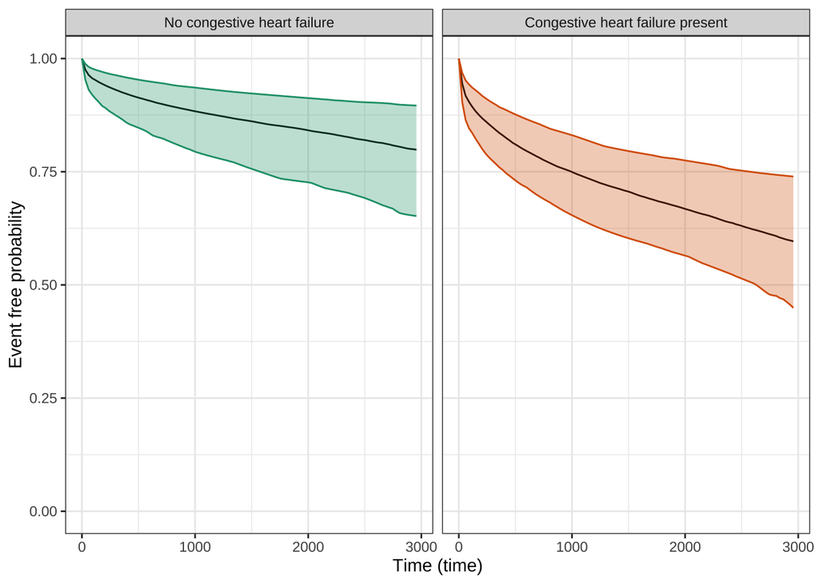

```r
panel_labels <- c('1' = "No congestive heart failure", '2' = "Congestive heart failure present")
pps <- plot(ps) +
  aes(colour = factor(id), fill = factor(id)) +
  scale_colour_brewer(palette = "Dark2") +
  scale_fill_brewer(palette = "Dark2") +
  theme(legend.position = "none") +
  facet_wrap(~ id, labeller = labeller(id = panel_labels))
print(pps)
```

## Check PH assumption visually

### make predictions of both the hazard and log hazard

```r
ph <- suppressWarnings(posterior_survfit(mod_chf3, newdata = nd, type = "haz"))
pl <- suppressWarnings(posterior_survfit(mod_chf3, newdata = nd, type = "loghaz"))
```

#### create plots

```r
pph <- plot(ph) +
  coord_cartesian(ylim = c(0.0, 0.005)) +
  facet_wrap(~ id, labeller = labeller(id = panel_labels))
```

```
## ℹ Adding new coordinate system, which will replace the existing one.
```

```r
ppl <- plot(pl) +
  facet_wrap(~ id, labeller = labeller(id = panel_labels))
```

#### combine plots in grid and plot

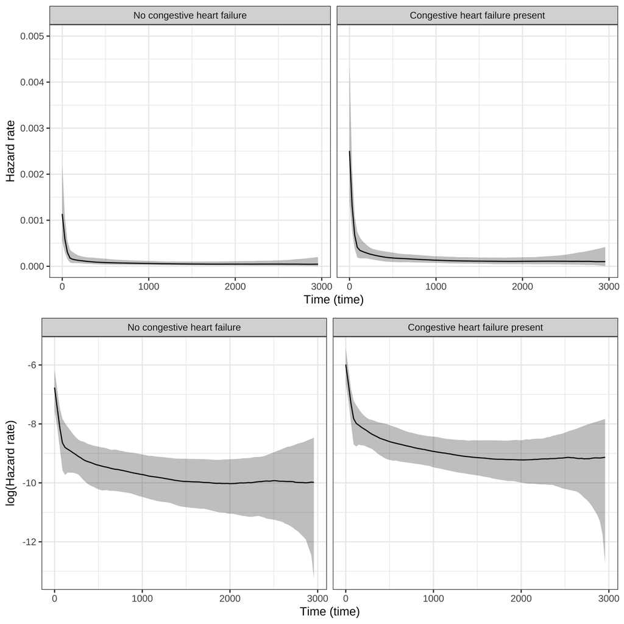

```r
plot_grid(pph, ppl, ncol = 1)
```